# team_12_nycflights13.qmd

# Task 1: Establishing a Productive Software Environment for the Project

## Task 1.1:

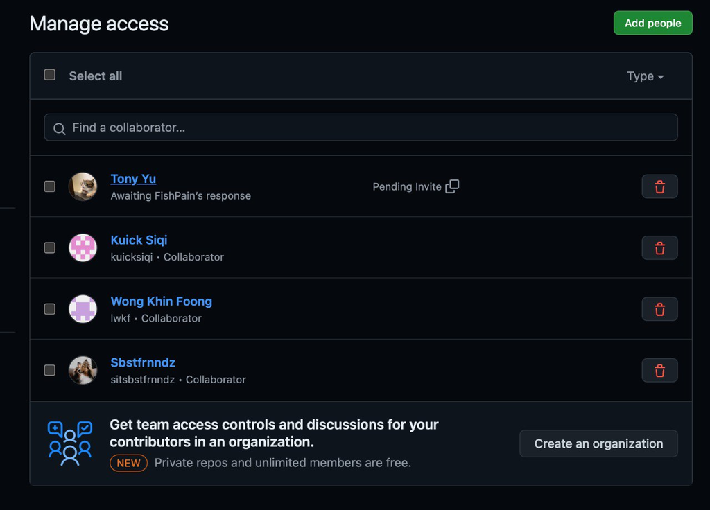

screenshot

## Task 1.2:

[figure not shown]

commit_screenshot

## Task 1.3: Connection code

```r
con_nycflights13 <- DBI::dbConnect(odbc::odbc(), dsn = "nycflights")
```

# Task 2

What are the rankings of New York City’s main airports in terms of the total number of destinations served? Include columns for the following attributes:

Three-letter airport code Airport name Number of destinations Rank

Sort the results first by rank and, then, alphabetically by the three-letter airport code. Hint: use INNER JOIN to get airport names from airports table.

```sql
SELECT
  a.faa AS airport_code,
  a.name AS airport_name,
  COUNT(f.dest) AS num_destinations,
  DENSE_RANK() OVER (ORDER BY COUNT(f.dest) DESC) AS rank
FROM
    airports a
INNER JOIN
    flights f
ON
    a.faa = f.origin
WHERE a.tzone = 'America/New_York'
GROUP BY a.faa;
```

3 records

| airport_code | airport_name | num_destinations | rank |
| --- | --- | --- | --- |
| EWR | Newark Liberty Intl | 113385 | 1 |
| JFK | John F Kennedy Intl | 89491 | 2 |
| LGA | La Guardia | 75101 | 3 |

Which ten destination airports are served by the greatest number of seats from New York City? If airports are tied for the tenth place, ensure that all tied airports are included in the output. Include columns for the following attributes:

Three-letter airport code Airport name Number of seats Rank Sort the results first by rank and, then, alphabetically by the three-letter airport code. Hint: the number of seats information is in planes.seats; same way as above to get airport names.

```sql
SELECT
  a.faa AS airport_code,
  a.name AS airport_name,
  SUM(p.seats) AS num_seats,
  DENSE_RANK() OVER (ORDER BY SUM(p.seats) DESC) AS rank
FROM
  airports a
INNER JOIN
  flights f
ON
  a.faa = f.dest
INNER JOIN
  planes p
ON
  f.tailnum = p.tailnum
WHERE a.tzone = 'America/New_York'
GROUP BY
  a.faa
LIMIT 10;
```

Displaying records 1 - 10

| airport_code | airport_name | num_seats | rank |
| --- | --- | --- | --- |
| MCO | Orlando Intl | 2362894 | 1 |
| CLT | Charlotte Douglas Intl | 2201151 | 2 |
| ATL | Hartsfield Jackson Atlanta Intl | 2103603 | 3 |
| FLL | Fort Lauderdale Hollywood Intl | 2081712 | 4 |
| TPA | Tampa Intl | 1153529 | 5 |
| BOS | General Edward Lawrence Logan Intl | 1141917 | 6 |
| PBI | Palm Beach Intl | 1121673 | 7 |
| DCA | Ronald Reagan Washington Natl | 906985 | 8 |
| MIA | Miami Intl | 887266 | 9 |
| DTW | Detroit Metro Wayne Co | 864188 | 10 |

What are the rankings of New York City’s main airports in terms of mean departure delay (highest delay first), weighting each flight equally when taking the average? Include columns for the following attributes:

Three-letter airport code Airport name Mean departure delay in minutes, rounded to two decimal places Rank Sort the results first by rank, and then, alphabetically by the three-letter airport code.

```sql
SELECT
    a.faa AS airport_code,
    a.name AS airport_name,
    ROUND(AVG(f.dep_delay), 2) AS mean_dep_delay,
    DENSE_RANK() OVER (ORDER BY AVG(f.dep_delay) DESC) AS rank
FROM
    airports a
INNER JOIN
    flights f
ON
    a.faa = f.origin
WHERE
    a.tzone = 'America/New_York'
GROUP BY
    a.faa, a.name
ORDER BY
    rank,
    airport_code;
```

3 records

| airport_code | airport_name | mean_dep_delay | rank |
| --- | --- | --- | --- |
| EWR | Newark Liberty Intl | 15.26 | 1 |
| JFK | John F Kennedy Intl | 12.35 | 2 |
| LGA | La Guardia | 11.29 | 3 |

Tabulate the percentage of on-time departures for each hour of the day when the plane is scheduled to leave. Include columns for the following attributes:

Hour of the day Percentage of on-time departures, rounded to two decimal places Sort the results by the hour of the day. Hint: use flights.sched_dep_time / 100 (integer division) to get the hour of the day, and you do not need to show the hours in which there is no scheduled departure.

```sql
SELECT
  f.sched_dep_time / 100 AS hour_of_day,
  ROUND(
    100.0 * SUM(
      CASE
        WHEN f.dep_delay <= 0 THEN 1
        ELSE 0
      END
    ) / COUNT(*),
    2
  ) AS on_time_pct
FROM
  flights f
GROUP BY
  f.sched_dep_time / 100
ORDER BY
  hour_of_day;
```

Displaying records 1 - 10

| hour_of_day | on_time_pct |
| --- | --- |
| 5 | 72.87 |
| 6 | 76.71 |
| 7 | 76.86 |
| 8 | 73.23 |
| 9 | 72.19 |
| 10 | 68.73 |
| 11 | 66.50 |
| 12 | 61.63 |
| 13 | 56.21 |
| 14 | 53.19 |

Which planes, identified by their tail number, were operated by more than one airline? Include columns for the following attributes:

Tail number Manufacturer Model Number of airlines (must be greater than 1) Sort the results alphabetically by tail number. Hint: DISTINCT flight carrier number per plane should be greater than 1.

```sql
SELECT
    p.tailnum AS tail_number,
    p.manufacturer,
    p.model,
    COUNT(DISTINCT f.carrier) AS num_airlines
FROM
    planes p
INNER JOIN
    flights f
ON
    p.tailnum = f.tailnum
GROUP BY
    p.tailnum, p.manufacturer, p.model
HAVING
    COUNT(DISTINCT f.carrier) > 1
ORDER BY
    tail_number;
```

Displaying records 1 - 10

| tail_number | manufacturer | model | num_airlines |
| --- | --- | --- | --- |
| N146PQ | BOMBARDIER INC | CL-600-2D24 | 2 |
| N153PQ | BOMBARDIER INC | CL-600-2D24 | 2 |
| N176PQ | BOMBARDIER INC | CL-600-2D24 | 2 |
| N181PQ | BOMBARDIER INC | CL-600-2D24 | 2 |
| N197PQ | BOMBARDIER INC | CL-600-2D24 | 2 |
| N200PQ | BOMBARDIER INC | CL-600-2D24 | 2 |
| N228PQ | BOMBARDIER INC | CL-600-2D24 | 2 |
| N232PQ | BOMBARDIER INC | CL-600-2D24 | 2 |
| N933AT | BOEING | 717-200 | 2 |
| N935AT | BOEING | 717-200 | 2 |

# Task 3

Which airport names in the airports table contain the string ‘Chicago’? Create a view named chicago_airports to save the result, including only the faa and name columns.

```sql
DROP VIEW IF EXISTS chicago_airports;
```

```sql
CREATE VIEW chicago_airports AS
SELECT
    faa,
    name
FROM
    airports
WHERE
    name ILIKE '%Chicago%';
```

```sql
SELECT * FROM chicago_airports;
```

5 records

| faa | name |
| --- | --- |
| GYY | Gary Chicago International Airport |
| MDW | Chicago Midway Intl |
| ORD | Chicago Ohare Intl |
| PWK | Chicago Executive |
| RFD | Chicago Rockford International Airport |

How many flights departed from New York City to each of Chicago’s airports? Include columns for the following attributes:

Three-letter code of the destination airport Name of the destination airport Number of flights Rank Sort the results first by rank and, then, alphabetically by the three-letter code of the destination airport.

```sql
select
    f.dest,
    a.name,
    count(*) as num_flights,
    dense_rank() over (order by count(*) desc) as rank
from
    flights f
inner join
    chicago_airports a
on
    f.dest = a.faa
where
    f.origin in ('JFK', 'LGA', 'EWR')
group by
    f.dest, a.name
order by
    rank, f.dest;
```

2 records

| dest | name | num_flights | rank |
| --- | --- | --- | --- |
| ORD | Chicago Ohare Intl | 11189 | 1 |
| MDW | Chicago Midway Intl | 4102 | 2 |

Which airlines operated flights from New York City to Chicago? Include columns for the following attributes:

Two-letter airline code Airline name Number of flights Rank Sort the results first by rank and, then, alphabetically by the two-letter airline code.

```sql
SELECT
    f.carrier AS airline_code,
    a.name AS airline_name,
    COUNT(*) AS num_flights,
    DENSE_RANK() OVER (ORDER BY COUNT(*) DESC) AS rank
FROM
    flights f
INNER JOIN
    airlines a
ON
    f.carrier = a.carrier
WHERE
    f.origin IN ('JFK', 'LGA', 'EWR') AND f.dest IN (SELECT faa FROM chicago_airports)
GROUP BY
    f.carrier, a.name
ORDER BY
    rank, airline_code;
```

8 records

| airline_code | airline_name | num_flights | rank |
| --- | --- | --- | --- |
| UA | United Air Lines Inc. | 6752 | 1 |
| WN | Southwest Airlines Co. | 4102 | 2 |
| AA | American Airlines Inc. | 2500 | 3 |
| 9E | Endeavor Air Inc. | 989 | 4 |
| B6 | JetBlue Airways | 898 | 5 |
| MQ | Envoy Air | 47 | 6 |
| EV | ExpressJet Airlines Inc. | 2 | 7 |
| OO | SkyWest Airlines Inc. | 1 | 8 |

```sql
SELECT
    p.manufacturer,
    p.model,
    COUNT(*) AS num_flights,
    DENSE_RANK() OVER (ORDER BY ROUND(
        100.0 * SUM(
            CASE
                WHEN f.arr_delay <= 0 THEN 1
                ELSE 0
            END
        ) / COUNT(*),
        2
    ) DESC) AS rank
FROM
    flights f
INNER JOIN
    planes p
ON
    f.tailnum = p.tailnum
WHERE
    f.origin IN ('JFK', 'LGA', 'EWR') AND f.dest IN (SELECT faa FROM chicago_airports
    )
GROUP BY
    p.manufacturer, p.model
HAVING
    COUNT(*) >= 100
ORDER BY
    rank, p.manufacturer, p.model;
```

Displaying records 1 - 10

| manufacturer | model | num_flights | rank |
| --- | --- | --- | --- |
| MCDONNELL DOUGLAS | DC-9-82(MD-82) | 1433 | 1 |
| AIRBUS | A319-131 | 189 | 2 |
| BOEING | 737-924ER | 308 | 3 |
| AIRBUS INDUSTRIE | A319-131 | 1946 | 4 |
| MCDONNELL DOUGLAS | DC-9-83(MD-83) | 701 | 5 |
| AIRBUS INDUSTRIE | A320-232 | 1743 | 6 |
| BOEING | 737-924 | 101 | 7 |
| BOEING | 757-224 | 358 | 8 |
| BOEING | 757-222 | 203 | 9 |
| BOEING | 737-724 | 613 | 10 |

Was at least one departure from New York City to Chicago scheduled every day in 2013? Provide your answer in the form of a table with one row and one column, containing the value TRUE or FALSE. Hint: use CASE to generate TRUE or FASLE. Combine month and day to get everyday in 2013.

```sql
SELECT
    CASE
        WHEN COUNT(*) = 365 THEN 'TRUE'
        ELSE 'FALSE'
    END AS is_scheduled_everyday
FROM (
    SELECT DISTINCT
        f.year,
        f.month,
        f.day
    FROM
        flights f
    WHERE
        f.origin IN ('JFK', 'LGA', 'EWR')
        AND f.dest in (SELECT faa FROM chicago_airports)
        AND f.year = 2013
) AS daily_flights;
```

1 records

| is_scheduled_everyday |
| --- |
| TRUE |

# Task 4

How many combinations of origin airport and time_hour are present in the flights table but absent from the weather table? Provide your answer in the form of a table with one row and one column

```sql
SELECT
    COUNT(*) AS num_combinations
FROM (
    SELECT DISTINCT
        f.origin,
        f.time_hour
    FROM
        flights f
    EXCEPT
    SELECT DISTINCT
        w.origin,
        w.time_hour
    FROM
        weather w
) AS missing_combinations;
```

1 records

| num_combinations |
| --- |
| 101 |

What is the percentage of on-time departures from each of New York City’s main airports under dry conditions (i.e., precip = 0) and under wet conditions? Include columns for the following attributes:

Three-letter airport code Airport name is_dry: Boolean values indicating zero precipitation. Percentage of on-time departures, rounded to two decimal places

First, sort the results alphabetically by the three-letter airport code and, then, by the presence of precipitation.

```sql
SELECT
    a.faa AS airport_code,
    a.name AS airport_name,
    w.precip = 0 AS is_dry,
    ROUND(
        100.0 * SUM(
            CASE
                WHEN f.dep_delay <= 0 THEN 1
                ELSE 0
            END
        ) / COUNT(*),
        2
    ) AS on_time_pct
FROM
    flights f
INNER JOIN
    airports a ON f.origin = a.faa
INNER JOIN
    weather w ON f.origin = w.origin AND f.time_hour = w.time_hour
WHERE
    a.faa IN ('JFK', 'LGA', 'EWR')
GROUP BY
    a.faa, a.name, w.precip = 0
ORDER BY
    a.faa, w.precip = 0;
```

6 records

| airport_code | airport_name | is_dry | on_time_pct |
| --- | --- | --- | --- |
| EWR | Newark Liberty Intl | 0 | 34.63 |
| EWR | Newark Liberty Intl | 1 | 55.08 |
| JFK | John F Kennedy Intl | 0 | 43.26 |
| JFK | John F Kennedy Intl | 1 | 62.18 |
| LGA | La Guardia | 0 | 41.00 |
| LGA | La Guardia | 1 | 65.96 |

How do New York City’s main airports rank in terms of mean departure delay when the visibility was less than one mile? Include columns for the following attributes:

Three-letter airport code Airport name Mean departure delay in minutes, rounded to two decimal places Rank Sort the results first by rank (starting with the smallest delay) and, then, alphabetically by the three-letter airport code.

```sql
SELECT
    a.faa AS airport_code,
    a.name AS airport_name,
    ROUND(AVG(f.dep_delay), 2) AS mean_dep_delay,
    DENSE_RANK() OVER (ORDER BY AVG(f.dep_delay)) AS rank
FROM
    flights f
INNER JOIN
    airports a ON f.origin = a.faa
INNER JOIN
    weather w ON f.origin = w.origin AND f.time_hour = w.time_hour
WHERE
    a.tzone = 'America/New_York' AND w.visib < 1
GROUP BY
    a.faa, a.name
ORDER BY
    rank, airport_code;
```

3 records

| airport_code | airport_name | mean_dep_delay | rank |
| --- | --- | --- | --- |
| LGA | La Guardia | 27.79 | 1 |
| JFK | John F Kennedy Intl | 29.01 | 2 |
| EWR | Newark Liberty Intl | 33.41 | 3 |

What is the correlation coefficient between the mean temperature of the day and the mean departure delay on that day? Round the value to two decimal places. Provide the answer in the form of a table with one row and one column. Hint: calculate the AVG() of temperature for each day in 2013, and then the AVG() of departure delay for each day in 2013. After that, calculate the CORR() between these two sequences (of length 365 or less). Remember to INNER JOIN flights and weather.

```sql
SELECT
    ROUND(CAST(CORR(daily_weather.temp, daily_flights.dep_delay) AS numeric), 2) AS correlation_coefficient
FROM (
    SELECT
        f.year,
        f.month,
        f.day,
        AVG(w.temp) AS temp
    FROM
        flights f
    INNER JOIN
        weather w ON f.origin = w.origin AND f.time_hour = w.time_hour
    WHERE
        f.year = 2013
    GROUP BY
        f.year, f.month, f.day
) AS daily_weather
INNER JOIN (
    SELECT
        f.year,
        f.month,
        f.day,
        AVG(f.dep_delay) AS dep_delay
    FROM
        flights f
    WHERE
        f.year = 2013
    GROUP BY
        f.year, f.month, f.day
) AS daily_flights ON daily_weather.year = daily_flights.year AND daily_weather.month = daily_flights.month AND daily_weather.day = daily_flights.day;
```

1 records

| correlation_coefficient |
| --- |
| 0.15 |

Burlington, Vermont, lies almost exactly to the north of New York City. Is the mean flight time to Burlington International Airport (BTV) shorter when the wind blows from the south (between 135 and 225 degrees) compared to when it blows from the north (between 0 and 45 degrees as well as between 315 and 360 degrees)? Provide your answer in the form of a table with one row each for north and south winds, and two columns, named wind_direction and mean_air_time. Hint: CASE expression.

```sql
SELECT
    wind_direction,
    ROUND(AVG(air_time), 2) AS mean_air_time
FROM (
    SELECT
        f.air_time,
        CASE
            WHEN w.wind_dir >= 135 AND w.wind_dir <= 225 THEN 'south'
            WHEN w.wind_dir >= 0 AND w.wind_dir <= 45 THEN 'north'
            WHEN w.wind_dir >= 315 AND w.wind_dir <= 360 THEN 'north'
            ELSE NULL
        END AS wind_direction
    FROM
        flights f
    INNER JOIN
        weather w ON f.origin = w.origin AND f.time_hour = w.time_hour
    WHERE
        f.dest = 'BTV'
) AS flight_wind
WHERE
    wind_direction IS NOT NULL
GROUP BY
    wind_direction;
```

2 records

| wind_direction | mean_air_time |
| --- | --- |
| north | 46.30 |
| south | 46.34 |

## Disconnect from Database

```r
DBI::dbDisconnect(con_nycflights13)
```